# Assignment_5

Priya Shaji

2/28/2019

## Tidying and Transforming Data

### loading the required packages

```r
#install.packages("tidyr")
#install.packages("dplyr")
library(tidyr)
library(dplyr)
```

### Dataset

#### Create a dataframe and load the dataset from the .csv file

```r
df_flight_wide <- read.csv("/Users/priyashaji/Documents/cuny msds/Spring'19/data 607/assignments/assignment_5/FlightsInfo - Sheet1.csv",header=TRUE,stringsAsFactors = FALSE)
df_flight_wide
```

```
##         X     X.1 Los.Angeles Phoenix San.Diego San.Franciso Seattle
## 1  ALASKA on time         497     221       212          503   1,841
## 2         delayed          62      12        20          102     305
## 3 AM WEST on time         694   4,840       383          320     201
## 4         delayed         117     415        65          129      61
```

### Tidying and Transforming data

Using functions provided by tidyr and dplyr packages The current dataframe: df_flight is a wide format of data We will use gather() function of tidyr package to make the data in long format

gather() function uses the folowing arguments:

data: Data object

key: Name of new key column (made from names of data columns)

value: Name of new value column

Names of source columns that contain values

factor_key: Treat the new key column as a factor (instead of character vector)

```r
df_flight_long <- gather(df_flight_wide, city, number, Los.Angeles:Seattle, factor_key=TRUE)
df_flight_long
```

```
##          X     X.1         city number
## 1   ALASKA on time  Los.Angeles    497
## 2          delayed  Los.Angeles     62
## 3  AM WEST on time  Los.Angeles    694
## 4          delayed  Los.Angeles    117
## 5   ALASKA on time      Phoenix    221
## 6          delayed      Phoenix     12
## 7  AM WEST on time      Phoenix  4,840
## 8          delayed      Phoenix    415
## 9   ALASKA on time    San.Diego    212
## 10         delayed    San.Diego     20
## 11 AM WEST on time    San.Diego    383
## 12         delayed    San.Diego     65
## 13  ALASKA on time San.Franciso    503
## 14         delayed San.Franciso    102
## 15 AM WEST on time San.Franciso    320
## 16         delayed San.Franciso    129
## 17  ALASKA on time      Seattle  1,841
## 18         delayed      Seattle    305
## 19 AM WEST on time      Seattle    201
## 20         delayed      Seattle     61
```

rename the columns

```r
colnames(df_flight_long)[2] <- "Status"
colnames(df_flight_long)[1] <- "Airline"
df_flight_long$Airline <- factor(df_flight_long$Airline)
df_flight_long
```

```
##    Airline  Status         city number
## 1   ALASKA on time  Los.Angeles    497
## 2          delayed  Los.Angeles     62
## 3  AM WEST on time  Los.Angeles    694
## 4          delayed  Los.Angeles    117
## 5   ALASKA on time      Phoenix    221
## 6          delayed      Phoenix     12
## 7  AM WEST on time      Phoenix  4,840
## 8          delayed      Phoenix    415
## 9   ALASKA on time    San.Diego    212
## 10         delayed    San.Diego     20
## 11 AM WEST on time    San.Diego    383
## 12         delayed    San.Diego     65
## 13  ALASKA on time San.Franciso    503
## 14         delayed San.Franciso    102
## 15 AM WEST on time San.Franciso    320
## 16         delayed San.Franciso    129
## 17  ALASKA on time      Seattle  1,841
## 18         delayed      Seattle    305
## 19 AM WEST on time      Seattle    201
## 20         delayed      Seattle     61
```

As we see in the above dataframe, “Airline” has alternate missing values. In order to fill the missing values from the Airline name previous to it, we use na.locf(.) function. Therefore, we first install the package “zoo”

na.locf(.) :

Last Observation Carried Forward Generic function for replacing each NA with the most recent non-NA prior to it.

```r
#install.packages("zoo")
library(zoo)
df_flight_long[df_flight_long$Airline=="","Airline"] <- NA
df_flight_long <- df_flight_long %>%
  do(na.locf(.))
df_flight_long
```

```
##    Airline  Status         city number
## 1   ALASKA on time  Los.Angeles    497
## 2   ALASKA delayed  Los.Angeles     62
## 3  AM WEST on time  Los.Angeles    694
## 4  AM WEST delayed  Los.Angeles    117
## 5   ALASKA on time      Phoenix    221
## 6   ALASKA delayed      Phoenix     12
## 7  AM WEST on time      Phoenix  4,840
## 8  AM WEST delayed      Phoenix    415
## 9   ALASKA on time    San.Diego    212
## 10  ALASKA delayed    San.Diego     20
## 11 AM WEST on time    San.Diego    383
## 12 AM WEST delayed    San.Diego     65
## 13  ALASKA on time San.Franciso    503
## 14  ALASKA delayed San.Franciso    102
## 15 AM WEST on time San.Franciso    320
## 16 AM WEST delayed San.Franciso    129
## 17  ALASKA on time      Seattle  1,841
## 18  ALASKA delayed      Seattle    305
## 19 AM WEST on time      Seattle    201
## 20 AM WEST delayed      Seattle     61
```

```r
# convert the column "number" from type "character" to type "numeric"
df_flight_long$number<-suppressWarnings(as.numeric(df_flight_long$number))
is.numeric(df_flight_long$number)
```

```
## [1] TRUE
```

Our dataframe is in long format now, we can apply dataset

We will use the spread() function.

spread() returns a copy of your data set that has had the key and value columns removed. In their place, spread() adds a new column for each unique value of the key column. These unique values will form the column names of the new columns. spread() distributes the cells of the former value column across the cells of the new columns and truncates any non-key, non-value columns in a way that prevents duplication.

```r
df_flight <- spread(df_flight_long, "Status", "number")

is.factor(df_flight$Airline)
```

```
## [1] TRUE
```

```r
is.numeric(df_flight$`on time`)
```

```
## [1] TRUE
```

```r
is.numeric(df_flight$delayed)
```

```
## [1] TRUE
```

```r
is.factor(df_flight$city)
```

```
## [1] TRUE
```

```r
df_flight
```

```
##    Airline         city delayed on time
## 1   ALASKA  Los.Angeles      62     497
## 2   ALASKA      Phoenix      12     221
## 3   ALASKA    San.Diego      20     212
## 4   ALASKA San.Franciso     102     503
## 5   ALASKA      Seattle     305      NA
## 6  AM WEST  Los.Angeles     117     694
## 7  AM WEST      Phoenix     415      NA
## 8  AM WEST    San.Diego      65     383
## 9  AM WEST San.Franciso     129     320
## 10 AM WEST      Seattle      61     201
```

### Analysis of flight status

Analysis to compare the arrival delays for the two airlines

Using the pipe(%>%) operator to do the analysis

```r
delay_analysis<- as.data.frame(df_flight %>%
  mutate(total = delayed + `on time`) %>%
  group_by(Airline,city) %>%
  summarise(delayed_total = sum(delayed),
            on_time_total = sum(`on time`),
            count_total = sum(total),
            percent_ontime = round(on_time_total/count_total*100,digit = 2),
 percent_delayed = round(delayed_total/count_total*100,digit = 2)         ))
delay_analysis
```

```
##    Airline         city delayed_total on_time_total count_total
## 1   ALASKA  Los.Angeles            62           497         559
## 2   ALASKA      Phoenix            12           221         233
## 3   ALASKA    San.Diego            20           212         232
## 4   ALASKA San.Franciso           102           503         605
## 5   ALASKA      Seattle           305            NA          NA
## 6  AM WEST  Los.Angeles           117           694         811
## 7  AM WEST      Phoenix           415            NA          NA
## 8  AM WEST    San.Diego            65           383         448
## 9  AM WEST San.Franciso           129           320         449
## 10 AM WEST      Seattle            61           201         262
##    percent_ontime percent_delayed
## 1           88.91           11.09
## 2           94.85            5.15
## 3           91.38            8.62
## 4           83.14           16.86
## 5              NA              NA
## 6           85.57           14.43
## 7              NA              NA
## 8           85.49           14.51
## 9           71.27           28.73
## 10          76.72           23.28
```

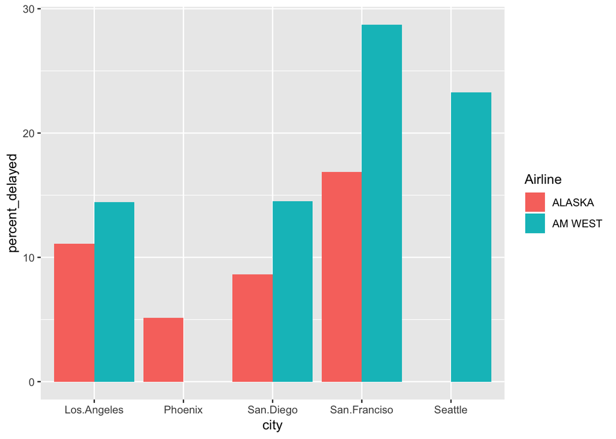

```r
library(ggplot2)
delays <- ggplot(delay_analysis,aes(x = city, y = percent_delayed))
suppressWarnings(delays + geom_bar(stat = "identity", position="dodge", aes(fill = Airline)))
```

#### Conclusion

As we can see by the graph, the delayed rate of AM WEST is higher than ALASKA Airline.